# Exploratory Graph Analysis

Daniel van der Meer, Fridtjof Petersen, Jonas Petter

4/26/2022

## Introduction to exploratory graph analysis

This markdown document illustrates how to apply exploratory graph analysis (EGA) using R. EGA was proposed as an alternative to common methods of exploratory factor analysis. EGA is based on the insight that latent variables are reflected as clusters in network models.

## The dataset

```r
library(lavaan)
data <- HolzingerSwineford1939[7:15]
```

In this example, we will use the data set from Holzinger and Swineford (1939), which comes with the R package *lavaan*. The researchers measured 300 students on their cognitive abilities, using a 9-item-questionnaire. These 9 items are assumed to correspond to visual, verbal and speed abilities. This 3 factor structure is indeed known to achieve a high fit with the data set. Thus, we hope to recover this 3 factor structure using EGA.

## Applying exploratory graph analysis step-by-step

The following code is adapted from Golino and Epskamp (2017).

Since EGA investigates clusters in network models, we first need to create a network model of the data. For this we need to get the correlation matrix of the 9 items. This is easily achieve with the *cor_auto* function from *qgraph*.

```r
library(qgraph)
correlation_matrix <- cor_auto(data)
```

Then, we can estimate the Gaussian graphical model, a network model, using the graphical lasso method. For this, we can use the *EBICglasso* function from *qgraph*.

```r
glasso <- EBICglasso(S=correlation_matrix, n = nrow(data))
```

Let us take a look at our estimated network model, using the qgraph function.

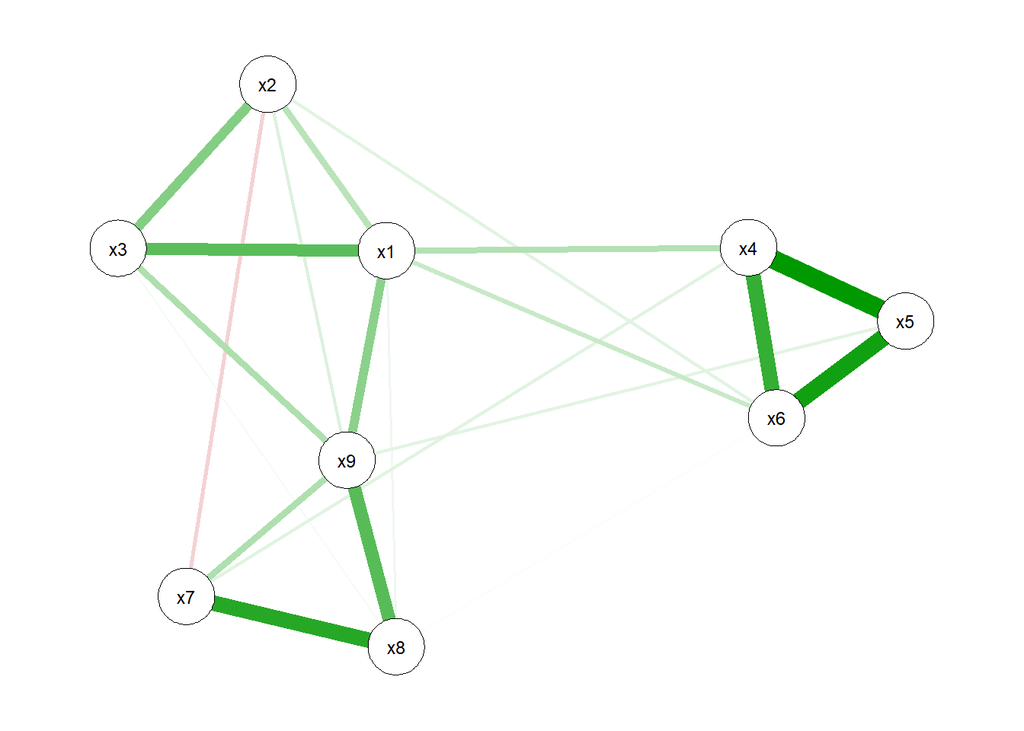

```r
networkGraph <- qgraph(glasso, layout = "spring", vsize = 6)
```

We can already see that the clusters in this network model correspond to our assumed factor structure. But to verify this mathematically, we need to take a few more steps. To obtain clusters from a network, EGA uses the walktrap algorithm. This algorithm is implemented in the *igraph* package. To use it, we need to convert our network model to the igraph notation and then use the *walktrap.community* function.

```r
library(igraph)
igraph <- as.igraph(networkGraph)
walktrapResults <- walktrap.community(igraph)
walktrapResults
```

```
## IGRAPH clustering walktrap, groups: 3, mod: 0.43
## + groups:
##   $`1`
##   [1] 7 8 9
##
##   $`2`
##   [1] 1 2 3
##
##   $`3`
##   [1] 4 5 6
##
```

The results tell us that there were indeed 3 clusters. This corresponds to a 3 factor structure, as expected. Factor 1 loads onto items 7, 8 and 9. Factor 2 loads onto items 1, 2 and 3. Factor 3 loads onto items 4, 5 and 6. This is in line with the proposed factor structure of visual, verbal and speed abilities. Finally, let us visualize the clusters using *qgraph*.

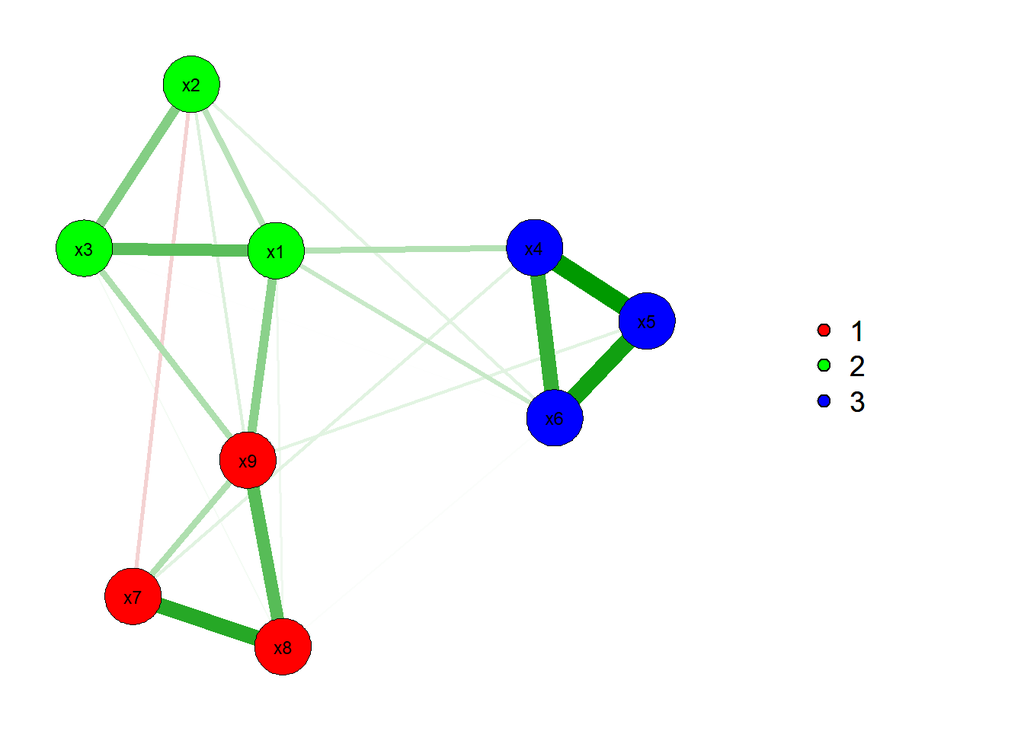

```r
qgraph(glasso, layout = "spring", vsize = 6, groups = as.factor(walktrapResults$membership))
```

## Packages for exploratory graph analysis

Fortunately, it is not necessary to go through all of the steps of EGA manually. Golino et al. have authored the R package *EGAnet*, which implements the EGA framework in a single function. This function gives us the same output as in the previous section, but with much less code.

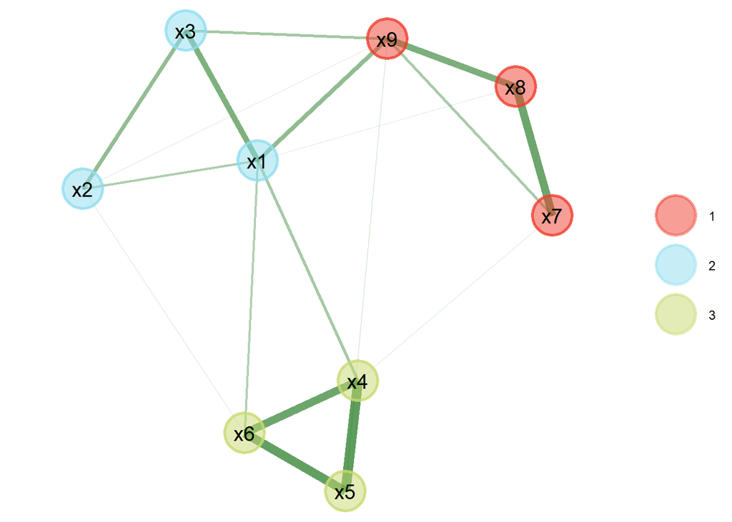

```
## EGA Results:
##
## Number of Dimensions:
## [1] 3
##
## Items per Dimension:
##    items dimension
## x7    x7         1
## x8    x8         1
## x9    x9         1
## x1    x1         2
## x2    x2         2
## x3    x3         2
## x4    x4         3
## x5    x5         3
## x6    x6         3
```

```r
library(EGAnet)
EGAnet::EGA(data, model = "glasso", plot.EGA = TRUE)
```

## Comparison with other methods